# Data and Transformations

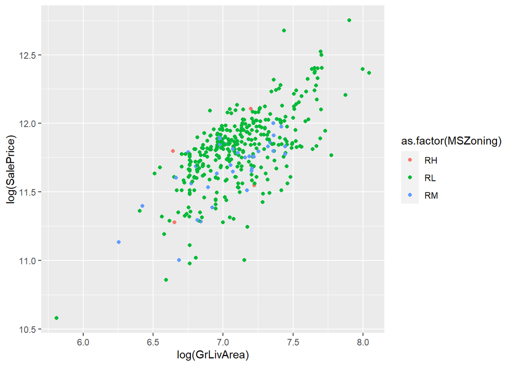

```r
# color - MS ZONING - RL (not a detriment for us here) - RESIDENTIAL LOW DENSITY
n3homedf_noout %>% ggplot(aes(log(GrLivArea),log(SalePrice),  color = as.factor(MSZoning))) +
  geom_point()
```

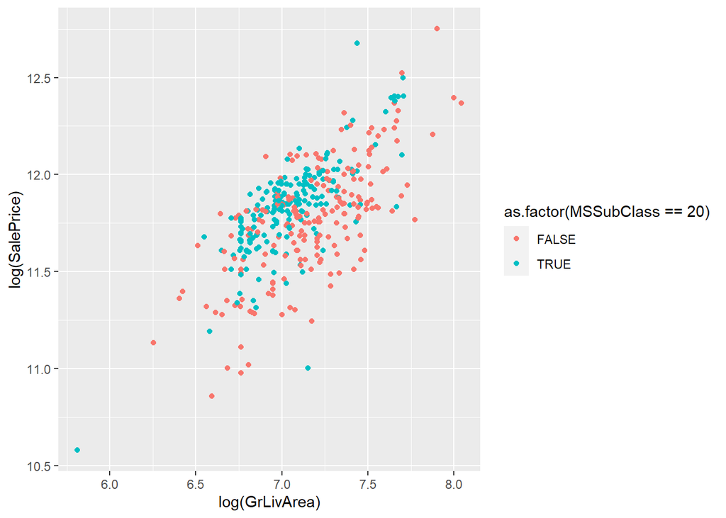

```r
# color - MS SUBCLASS - 20 - 1 story 1946 & Newer & newer all styles
n3homedf_noout %>% ggplot(aes(log(GrLivArea),log(SalePrice),  color = as.factor(MSSubClass == 20))) +
  geom_point()
```

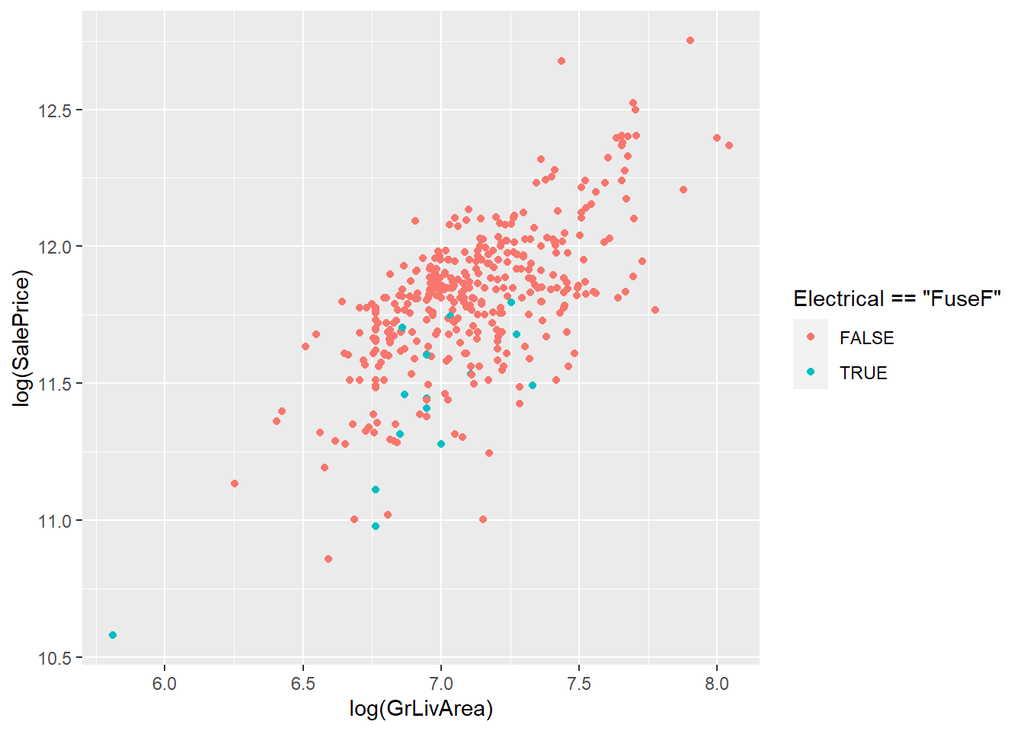

```r
# color - ELECTRICAL - FuseF - 60 AMP Fuse Box and mostly Romex Wiring (Fair)
n3homedf_noout %>% ggplot(aes(log(GrLivArea),log(SalePrice),  color = Electrical == "FuseF")) +
  geom_point()
```

After visually understanding some of the features of the outlier home in question, it is to our understanding that while the home is not “part of” the majority of the dataset in terms of where most of the point lie, it is not due to some abnormality that we can see or understand given the data. In other words, the reasons for the abnormal point of this data seem to be due to certain features of the home/land/plot and the small GrLivArea (squarefootage), so we will proceed with this point in the data and may consider a model which includes and excludes it.

Next we will build a model that will determine if the squarefootage of the living area and its Sale Price is dependent on which Neighborhood it is in.

To do this it will help first to test if all the regression lines are parallel. if they are, then we can check for a differnce in Sale Price across all Neighborhoods by looking at the intercept.

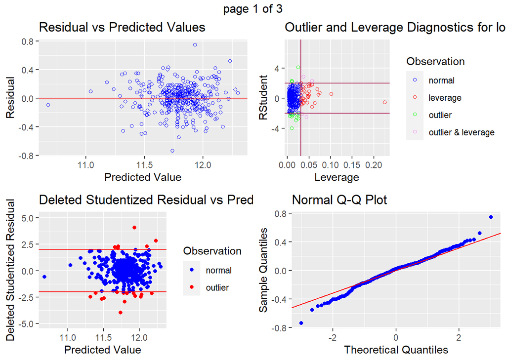

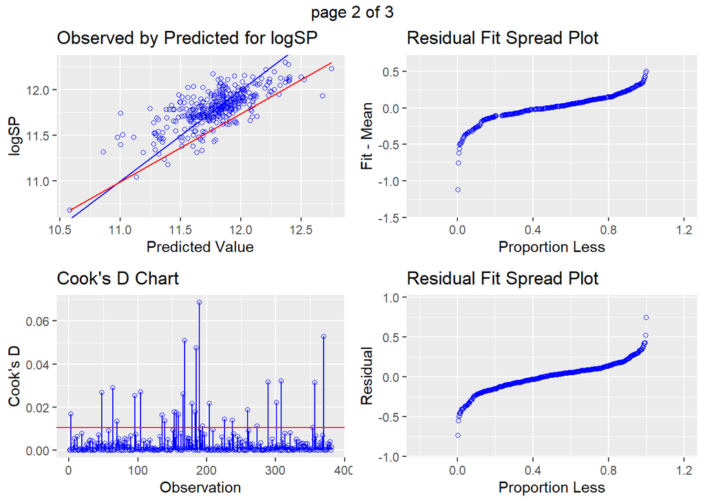

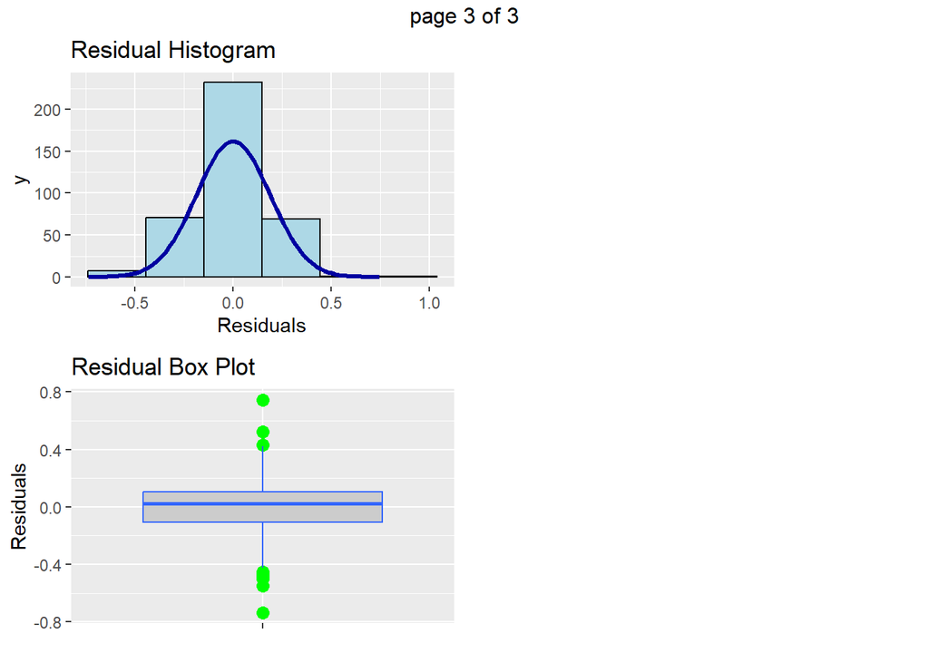

```r
# full model
# creating log var
n3homedf_noout$logGLA <- log(n3homedf_noout$GrLivArea)
n3homedf_noout$logSP <- log(n3homedf_noout$SalePrice)
# setting Neighborhood as factor to use as ref.
n3homedf_noout$Neighborhood <- as.factor(n3homedf_noout$Neighborhood)

full_model <- lm(logSP ~ logGLA * relevel(Neighborhood, ref = "Edwards"), data = n3homedf_noout)
ols_plot_diagnostics(full_model)
```

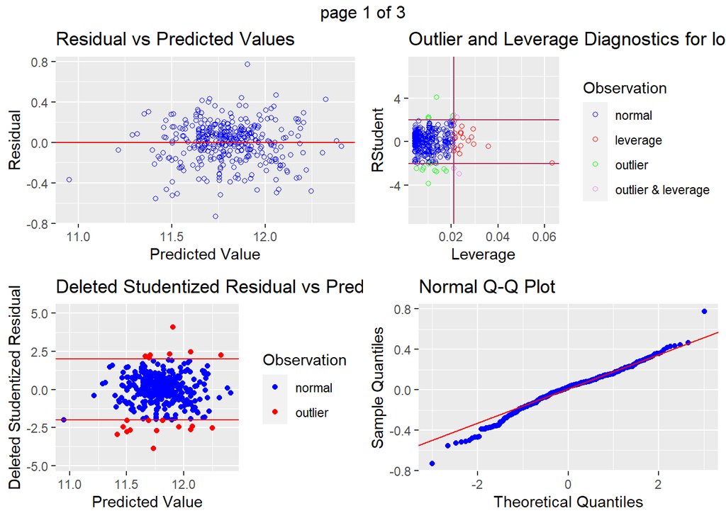

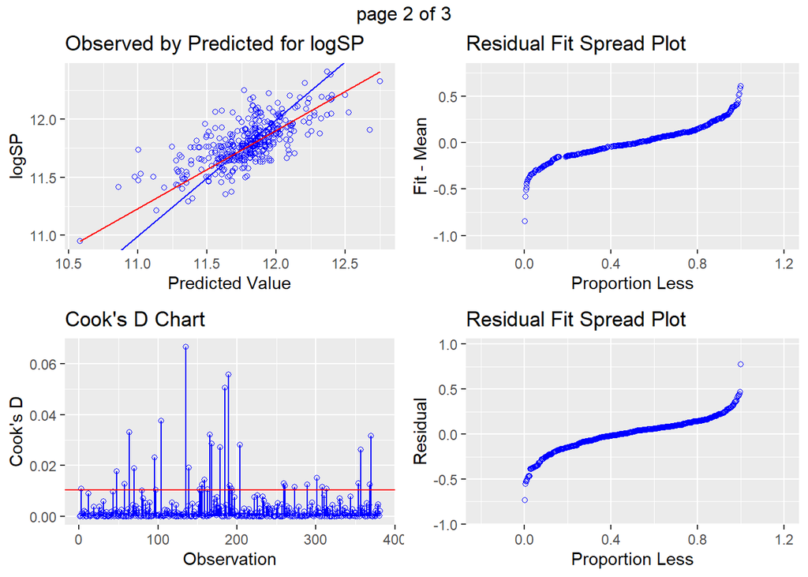

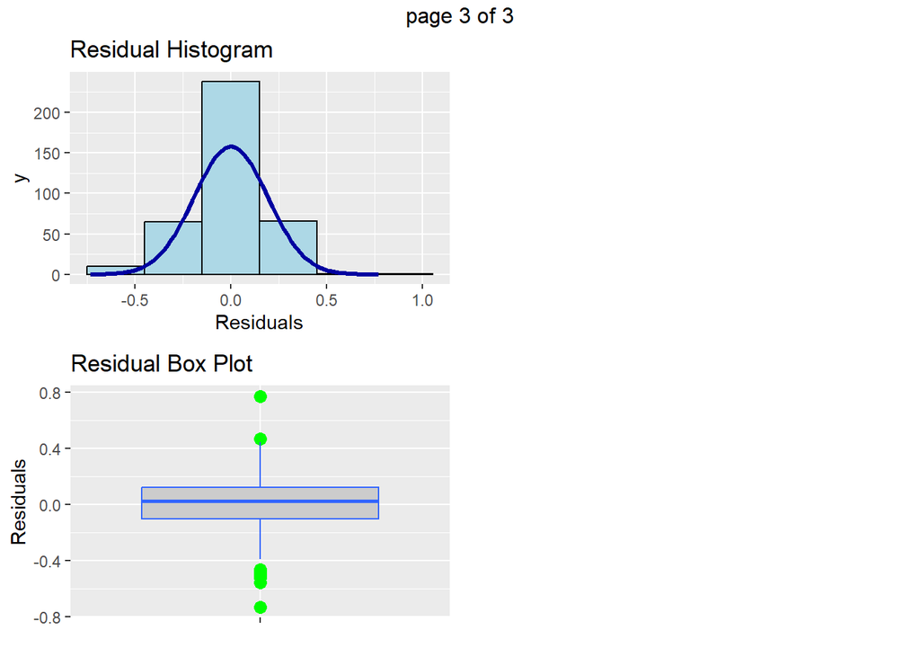

```r
#summary(full_model) # adj.R2 = .5216


# Reduced Model
red_model <- lm(logSP~logGLA + relevel(Neighborhood, ref = "Edwards"), data = n3homedf_noout)
ols_plot_diagnostics(red_model)
```

```r
#summary(red_model) # adj. R2 = .5002
```

after analysis of the full and reduced model, because the adjusted R^2 favors the model with the interaction parameters we will proceed with the full model going forward.

```r
# REDUCED MODEL
model_fit_stats <- function(linear.model) {
  r.sqr <- summary(linear.model)$r.squared
  adj.r.sqr <- summary(linear.model)$adj.r.squared
  pre.r.sqr <- pred_r_squared(linear.model)
  PRESS <- PRESS(linear.model)
  return.df <- data.frame(r.squared = r.sqr, adj.r.squared = adj.r.sqr, pred.r.squared = pre.r.sqr, press = PRESS)
  return(return.df)
}


pred_r_squared <- function(linear.model) {
  #' Use anova() to get the sum of squares for the linear model
  lm.anova <- anova(linear.model)
  #' Calculate the total sum of squares
  tss <- sum(lm.anova$'Sum Sq')
  # Calculate the predictive R^2
  pred.r.squared <- 1-PRESS(linear.model)/(tss)

  return(pred.r.squared)
}


PRESS <- function(linear.model) {
  #' calculate the predictive residuals
  pr <- residuals(linear.model)/(1-lm.influence(linear.model)$hat)
  #' calculate the PRESS
  PRESS <- sum(pr^2)

  return(PRESS)
}
# pred_r_squared(red_model) # pred r2
# PRESS(red_model)
#
# AIC(red_model)
#
model_fit_stats(red_model)
```

| r.squared | adj.r.squared | pred.r.squared | press |
| --- | --- | --- | --- |
| 0.504 | 0.5 | 0.491 | 14.5 |

```r
#summary(red_model)
```

```r
# FULL MODEL
model_fit_stats <- function(linear.model) {
  r.sqr <- summary(linear.model)$r.squared
  adj.r.sqr <- summary(linear.model)$adj.r.squared
  pre.r.sqr <- pred_r_squared(linear.model)
  PRESS <- PRESS(linear.model)
  return.df <- data.frame(r.squared = r.sqr, adj.r.squared = adj.r.sqr, pred.r.squared = pre.r.sqr, press = PRESS)
  return(return.df)
}


pred_r_squared <- function(linear.model) {
  #' Use anova() to get the sum of squares for the linear model
  lm.anova <- anova(linear.model)
  #' Calculate the total sum of squares
  tss <- sum(lm.anova$'Sum Sq')
  # Calculate the predictive R^2
  pred.r.squared <- 1-PRESS(linear.model)/(tss)

  return(pred.r.squared)
}
#pred_r_squared(red_model) # pred r2

PRESS <- function(linear.model) {
  #' calculate the predictive residuals
  pr <- residuals(linear.model)/(1-lm.influence(linear.model)$hat)
  #' calculate the PRESS
  PRESS <- sum(pr^2)

  return(PRESS)
}
#
# PRESS(full_model)
#
# AIC(full_model)

model_fit_stats(full_model)
```

| r.squared | adj.r.squared | pred.r.squared | press |
| --- | --- | --- | --- |
| 0.528 | 0.522 | 0.509 | 13.9 |

```r
#summary(full_model)
```

# Analysis 2

Feature Selection and testing for Custom Model: using correlative relationships we then put together a list of variables in which we deemed appropriate for integration into our custom model. After building our custom array of variables we broke our model into a test and train split then fit the forward model and then tested it against our test data before testing it against the true training data.

```r
custom_var = c('LogSalePrice','OverallQual','OverallCond','YearBuilt',
              'ExterCondNum','LogTotalBsmtSF','HeatingQCNum',
              'BedroomAbvGr','Fireplaces', 'LogGarageArea',
              "LogGrLivArea","LogWoodDeckSF","LogScreenPorch","LogLotArea")

custom_model = AmesHouesingDataFrame[,custom_var]

set.seed(4)
train.index = sample(c(1:dim(custom_model)[1]), dim(custom_model)[1]*0.8)
custom_model_train = custom_model[train.index,]
custom_model_test = custom_model[-train.index,]

home_fit = lm(LogSalePrice~.-LogSalePrice, data = custom_model_train)
# summary(home_regression)

pred1 = predict(home_fit,
                custom_model_test,
                type = "response")

residuals = custom_model_test$LogSalePrice - pred1

home_fit_prediction = data.frame("Predicted" = pred1,
                                  "Actual" = custom_model_test$LogSalePrice,
                                  "Residual" = residuals)

# returns ME-RMSE-MAE-MPE-MAPE
#accuracy(pred1, lr_model_test$LogSalePrice)

# note "predict" this returns fit/lwr/upr
#pred2 = predict(home_regression, interval = "predict", newdata = lr_model_test)
# summary(pred2)

#stargazer(home_regression, type = 'text')

#car::vif(home_regression)
```

Setting up Test Data for Predictions: Because we have transformed a lot of our training data, we need to make the same transformations to our testing data as well. this process included some NA handling, feature transformation and essentially all of the steps we performed above.

```r
hdata <- read.csv("C:/Users/Joey/Desktop/house-prices-advanced-regression-techniques/test.csv",header = TRUE)
#hdata <- read.csv("C:/SMU MS Data Science/StatisticalFoundations6371/AmesHousePricing/test.csv",header = TRUE)

# The data contain many NA values. These NA values are not necessarily missing data, but can be thought of as
# a missing feature of certain homes.

hdata$Fence <- as.character(hdata$Fence)
hdata$Fence[is.na(hdata$Fence)] <- "None"
hdata$Fence <- as.factor(hdata$Fence)

# MSZoning: Identifies the general zoning classification of the sale.
hdata$MSZoning <- as.character(hdata$MSZoning)
hdata$MSZoning[is.na(hdata$MSZoning)] <- "None"
hdata$MSZoning <- as.factor(hdata$MSZoning)

# Exterior1st: Exterior covering on house
hdata$Exterior1st <- as.character(hdata$Exterior1st)
hdata$Exterior1st[is.na(hdata$Exterior1st)] <- "None"
hdata$Exterior1st <- as.factor(hdata$Exterior1st)

#Exterior2nd: Exterior covering on house (if more than one material)
hdata$Exterior2nd <- as.character(hdata$Exterior2nd)
hdata$Exterior2nd[is.na(hdata$Exterior2nd)] <- "None"
hdata$Exterior2nd <- as.factor(hdata$Exterior2nd)

hdata$GarageType <- as.character(hdata$GarageType)
hdata$GarageType[is.na(hdata$GarageType)] <- "None"
hdata$GarageType <- as.factor(hdata$GarageType)

hdata$FireplaceQu <- as.character(hdata$FireplaceQu)
hdata$FireplaceQu[is.na(hdata$FireplaceQu)] <- "None"
hdata$FireplaceQu <- as.factor(hdata$FireplaceQu)

hdata$Alley <- as.character(hdata$Alley)
hdata$Alley[is.na(hdata$Alley)] <- "None"
hdata$Alley <- as.factor(hdata$Alley)

hdata$BsmtCond <- as.character(hdata$BsmtCond)
hdata$BsmtCond[is.na(hdata$BsmtCond)] <- "None"
hdata$BsmtCond <- as.factor(hdata$BsmtCond)

hdata$BsmtExposure <- as.character(hdata$BsmtExposure)
hdata$BsmtExposure[is.na(hdata$BsmtExposure)] <- "None"
hdata$BsmtExposure <- as.factor(hdata$BsmtExposure)

hdata$BsmtFinType1 <- as.character(hdata$BsmtFinType1)
hdata$BsmtFinType1[is.na(hdata$BsmtFinType1)] <- "None"
hdata$BsmtFinType1 <- as.factor(hdata$BsmtFinType1)

hdata$BsmtFinType2 <- as.character(hdata$BsmtFinType2)
hdata$BsmtFinType2[is.na(hdata$BsmtFinType2)] <- "None"
hdata$BsmtFinType2<- as.factor(hdata$BsmtFinType2)

hdata$GarageFinish <- as.character(hdata$GarageFinish)
hdata$GarageFinish[is.na(hdata$GarageFinish)] <- "None"
hdata$GarageFinish <- as.factor(hdata$GarageFinish)

hdata$GarageQual <- as.character(hdata$GarageQual)
hdata$GarageQual[is.na(hdata$GarageQual)] <- "None"
hdata$GarageQual <- as.factor(hdata$GarageQual)

hdata$GarageCond <- as.character(hdata$GarageCond)
hdata$GarageCond[is.na(hdata$GarageCond)] <- "None"
hdata$GarageCond <- as.factor(hdata$GarageCond)

hdata$MiscFeature <- as.character(hdata$MiscFeature)
hdata$MiscFeature[is.na(hdata$MiscFeature)] <- "None"
hdata$MiscFeature <- as.factor(hdata$MiscFeature)

hdata$MasVnrType <- as.character(hdata$MasVnrType)
hdata$MasVnrType[is.na(hdata$MasVnrType)] <- "None"
hdata$MasVnrType <- as.factor(hdata$MasVnrType)

hdata$LogX1stFlrSF = log(hdata$X1stFlrSF + 1)
hdata$LogX2ndFlrSF = log(hdata$X2ndFlrSF + 1)
hdata$LogGrLivArea = log(hdata$GrLivArea + 1)

hdata$LogTotalBsmtSF = log(hdata$TotalBsmtSF + 1)
hdata$LogBsmtUnfSF = log(hdata$BsmtUnfSF + 1)

hdata$LogWoodDeckSF = log(hdata$WoodDeckSF + 1)
hdata$LogOpenPorchSF = log(hdata$OpenPorchSF + 1)
hdata$LogX3SsnPorch = log(hdata$X3SsnPorch + 1)
hdata$LogScreenPorch = log(hdata$ScreenPorch + 1)

hdata$LogLotArea = log(hdata$LotArea + 1)
hdata$LogLotFrontage = log(hdata$LotFrontage + 1)

hdata$LogPoolArea = log(hdata$PoolArea + 1)

hdata$LogGarageArea = log(hdata$GarageArea + 1)

hdata$LogMasVnrArea = log(hdata$MasVnrArea + 1)

hdata$ExterCondNum <- as.numeric(factor(hdata$ExterCond,
                                                levels = c("Ex","Gd","TA","Fa","Po"),
                                                labels = c(5,4,3,2,1), ordered = TRUE))

hdata$HeatingQCNum <- as.numeric(factor(hdata$HeatingQC,
                                  levels = c("Ex", "Gd","TA", "Fa","Po"),
                                  labels = c(5,4,3,2,1) ,ordered = TRUE))

hdata$CentralAirNum <- as.numeric(factor(hdata$CentralAir,
                                  levels = c("N", "Y"),
                                  labels = c(0,1) ,ordered = TRUE))


hfit <- lm(LogSalePrice ~ .-LogSalePrice, data = custom_model)

hdata$SalePrice = as.numeric(NA)
hdata$lSalePrice = as.numeric(NA)

hpred <- predict(hfit, interval = "predict", newdata = hdata, na.action = na.omit )

h_prediction <- data.frame(cbind(hdata$Id, exp(hpred[,1]))) # the exp() is the back transform

names(h_prediction) <- c("ID", "SalePrice")

#write.csv(h_prediction, file = "./housePredictions.csv", row.names = FALSE)

# kaggle .28941
# CV PRESS 28.23967
# ADJ. R-SQUARE .8814423
```

Feature Selection and testing for Forward Model: using the forward selection method we put together a list of variables which met the forward selection criteria. Once our model was fit with the forward selection features we used it to perform predictions against the true test data.

```r
# ols_step_forward_p(home_fit, details = FALSE)
#
# var selected by forward selection methods

forward_var <- c("LogSalePrice","OverallQual","LogGrLivArea","YearBuilt","LogLotArea",
                 "OverallCond","BedroomAbvGr","LogTotalBsmtSF",
                 "Fireplaces","LogGarageArea","HeatingQCNum","LogScreenPorch",
                 "LogWoodDeckSF","CentralAirNum","TotRmsAbvGrd","KitchenAbvGr",
                 "LogMasVnrArea","YrSold")

lr_model_forw = AmesHouesingDataFrame[,forward_var]

model_forward <- lm(LogSalePrice ~ OverallQual+LogGrLivArea+YearBuilt+
                      LogLotArea + OverallCond +BedroomAbvGr+
                      LogTotalBsmtSF + Fireplaces + LogGarageArea +
                      HeatingQCNum +LogScreenPorch + LogWoodDeckSF+
                      CentralAirNum + TotRmsAbvGrd + KitchenAbvGr +
                      LogMasVnrArea + YrSold, data = lr_model_forw)


hdata$SalePrice = as.numeric(NA)
hdata$lSalePrice = as.numeric(NA)
FWPred <- predict(model_forward, interval = "predict", newdata = hdata, na.action = na.omit)

FWPrediction <- data.frame(cbind(hdata$Id, exp(FWPred[,1])))

names(FWPrediction) <- c("ID", "SalePrice")

# write.csv(FWPrediction, file = "./forwardPred.csv", row.names = FALSE)
# KAGGLE .42961
# R^2 .8823582
# adj. R^2 .8809616
# pred. R^2 .8788232
# CV PRESS 28.0415
```

Forward Selection Performance Stats: The code below contain functions that will return specific values in which we can measure performance for our model.

```r
# FORWARD MODEL STATS

pred_r_squared <- function(linear.model) {
  #' Use anova() to get the sum of squares for the linear model
  lm.anova <- anova(linear.model)
  #' Calculate the total sum of squares
  tss <- sum(lm.anova$'Sum Sq')
  # Calculate the predictive R^2
  pred.r.squared <- 1-PRESS(linear.model)/(tss)

  return(pred.r.squared)
}


PRESS <- function(linear.model) {
  #' calculate the predictive residuals
  pr <- residuals(linear.model)/(1-lm.influence(linear.model)$hat)
  #' calculate the PRESS
  PRESS <- sum(pr^2)

  return(PRESS)
}


model_fit_stats <- function(linear.model) {
  r.sqr <- summary(linear.model)$r.squared
  adj.r.sqr <- summary(linear.model)$adj.r.squared
  pre.r.sqr <- pred_r_squared(linear.model)
  PRESS <- PRESS(linear.model)
  return.df <- data.frame(r.squared = r.sqr, adj.r.squared = adj.r.sqr, pred.r.squared = pre.r.sqr, press = PRESS)
  return(return.df)
}
# pred_r_squared(model_forward)
#
# PRESS(model_forward)
#
# AIC(model_forward)

model_fit_stats(model_forward)
```

| r.squared | adj.r.squared | pred.r.squared | press |
| --- | --- | --- | --- |
| 0.882 | 0.881 | 0.879 | 28 |

Model Selection Methods : Stepwise Selection using the Stepwise selection method we put together a list of variables which met the Stepwise selection criteria. Once our model was fit with the Stepwise selection features we used it to perform predictions against the true test data.

```r
#ols_step_both_p(home_reg2,details = FALSE)

step_wise_var <- c("LogSalePrice","OverallQual","LogGrLivArea","YearBuilt",
                   "LogLotArea","OverallCond","BedroomAbvGr",
                   "LogTotalBsmtSF","Fireplaces","LogGarageArea",
                   "HeatingQCNum", "LogScreenPorch",
                   "LogWoodDeckSF","CentralAirNum","ExterCondNum")

lr_model_sw = AmesHouesingDataFrame[,step_wise_var]

model_stepwise <- lm(LogSalePrice ~ OverallQual + LogGrLivArea + YearBuilt + LogLotArea +
                       OverallCond + BedroomAbvGr + LogTotalBsmtSF + Fireplaces +
                       LogGarageArea + HeatingQCNum + LogScreenPorch + LogWoodDeckSF +
                       CentralAirNum + ExterCondNum , data = lr_model_sw)

# summary(model_stepwise)
hdata$SalePrice = as.numeric(NA)
hdata$lSalePrice = as.numeric(NA)
swPred <- predict(model_stepwise, interval = "predict", newdata = hdata, na.action = na.omit)

swPrediction <- data.frame(cbind(hdata$Id, exp(swPred[,1])))

names(swPrediction) <- c("ID", "SalePrice")

# write.csv(swPrediction, file = "./SWPred.csv", row.names = FALSE)
# kaggle score .28948
# rsquare .8811709
# adj. r square .8801841
# pred r square .878761
# cv press 28.22304
```

Stepwise Selection Performance Stats: The code below contain functions that will return specific values in which we can measure performance for our model.

```r
# STEP WISE STATS

pred_r_squared <- function(linear.model) {
  #' Use anova() to get the sum of squares for the linear model
  lm.anova <- anova(linear.model)
  #' Calculate the total sum of squares
  tss <- sum(lm.anova$'Sum Sq')
  # Calculate the predictive R^2
  pred.r.squared <- 1-PRESS(linear.model)/(tss)

  return(pred.r.squared)
}

PRESS <- function(linear.model) {
  #' calculate the predictive residuals
  pr <- residuals(linear.model)/(1-lm.influence(linear.model)$hat)
  #' calculate the PRESS
  PRESS <- sum(pr^2)

  return(PRESS)
}

model_fit_stats <- function(linear.model) {
  r.sqr <- summary(linear.model)$r.squared
  adj.r.sqr <- summary(linear.model)$adj.r.squared
  pre.r.sqr <- pred_r_squared(linear.model)
  PRESS <- PRESS(linear.model)
  return.df <- data.frame(r.squared = r.sqr, adj.r.squared = adj.r.sqr, pred.r.squared = pre.r.sqr, press = PRESS)
  return(return.df)
}
# pred_r_squared(model_stepwise)
#
# PRESS(model_stepwise)
#
# AIC(model_stepwise)

model_fit_stats(model_stepwise)
```

| r.squared | adj.r.squared | pred.r.squared | press |
| --- | --- | --- | --- |
| 0.882 | 0.881 | 0.879 | 28.2 |

Model Selection Methods : Backward Selection using the Backward selection method we put together a list of variables which met the Backward selection criteria. Once our model was fit with the Backward selection features we used it to perform predictions against the true test data.

```r
bk_var <- c('LogSalePrice','OverallQual','OverallCond','YearBuilt',
            'ExterCondNum','LogTotalBsmtSF','HeatingQCNum',
            'CentralAirNum','BedroomAbvGr','KitchenAbvGr',
            'TotRmsAbvGrd','Fireplaces', 'LogGarageArea',
            'YrSold', "LogGrLivArea","LogWoodDeckSF",
            "LogScreenPorch","LogLotArea","LogMasVnrArea")

lr_model_bk = AmesHouesingDataFrame[,bk_var]

model_bk <- lm(LogSalePrice ~ OverallQual + OverallCond + YearBuilt + ExterCondNum +
                       LogTotalBsmtSF+ HeatingQCNum+ CentralAirNum+
                 BedroomAbvGr + KitchenAbvGr + TotRmsAbvGrd + Fireplaces +
                 LogGarageArea + YrSold + LogGrLivArea + LogWoodDeckSF +LogScreenPorch +
                 LogLotArea + LogMasVnrArea, data = lr_model_bk)

# summary(model_bk)
hdata$SalePrice = as.numeric(NA)
hdata$lSalePrice = as.numeric(NA)
BWPred <- predict(model_bk, interval = "predict", newdata = hdata, na.action = na.omit)

BWPrediction <- data.frame(cbind(hdata$Id, exp(BWPred[,1])))

names(BWPrediction) <- c("ID", "SalePrice")

# write.csv(BWPrediction, file = "./BWPred.csv", row.names = FALSE)
# kaggle score .42936
# rsquare .8826054
# adj. r square .8811288
# pred r square .8787318
# cv press 28.06264
```

Backward Selection Performance Stats: The code below contain functions that will return specific values in which we can measure performance for our model.

```r
# BACKWARD PERFORMANCE STATS:


pred_r_squared <- function(linear.model) {
  #' Use anova() to get the sum of squares for the linear model
  lm.anova <- anova(linear.model)
  #' Calculate the total sum of squares
  tss <- sum(lm.anova$'Sum Sq')
  # Calculate the predictive R^2
  pred.r.squared <- 1-PRESS(linear.model)/(tss)

  return(pred.r.squared)
}


PRESS <- function(linear.model) {
  #' calculate the predictive residuals
  pr <- residuals(linear.model)/(1-lm.influence(linear.model)$hat)
  #' calculate the PRESS
  PRESS <- sum(pr^2)

  return(PRESS)
}


model_fit_stats <- function(linear.model) {
  r.sqr <- summary(linear.model)$r.squared
  adj.r.sqr <- summary(linear.model)$adj.r.squared
  pre.r.sqr <- pred_r_squared(linear.model)
  PRESS <- PRESS(linear.model)
  return.df <- data.frame(r.squared = r.sqr, adj.r.squared = adj.r.sqr, pred.r.squared = pre.r.sqr, press = PRESS)
  return(return.df)
}
# pred_r_squared(model_bk)
#
# PRESS(model_bk)
#
# AIC(model_bk)

model_fit_stats(model_bk)
```

| r.squared | adj.r.squared | pred.r.squared | press |
| --- | --- | --- | --- |
| 0.883 | 0.881 | 0.879 | 28.1 |